# 05.1-resazurin-multi_stress-curve-features-prediction

Steven Roberts 2026-09-22

- 1 Background
  - 1.1 Caveats (read first)
  - 1.2 Expected inputs
  - 1.3 Expected outputs
- 2 Setup
- 3 Helper Functions
- 4 Load Metabolism Data
- 5 Curve Feature Extraction
- 6 Screen: Which Features Separate the Six Stresses?
- 7 Each Stress on Its Own
  - 7.1 Stress feature profiles
  - 7.2 What sets each stress apart (one-vs-rest)
- 8 Cross-validated Prediction (leave-one-oyster-out)
  - 8.1 Best model: confusion matrix
- 9 Composite Stress Index
- 10 Synthesis
  - 10.1 Screening result
  - 10.2 Cross-validated result
  - 10.3 Each stress
  - 10.4 Interpretation
  - 10.5 Recommended next steps
- 11 Session info

# 1 Background

**Question:** *Does the shape of a resazurin curve identify which stress an oyster experienced, and which curve features carry that signal?*

This notebook applies the notebook-04 framework (feature screen → cross-validated prediction → composite index) to the 20260921 multi-stress run. 04 predicted a family’s *survival* from family-mean curve features. Here there is a single family and **six distinct stresses** (plates `C`, `R`, `S`, `T`, `U`, `V`), none of which is a control. The unit of prediction is therefore the **individual oyster**, and the target is **which of the six stresses** it was exposed to.

| 04 (family phenotype) | 05.1 (multi-stress) |
| --- | --- |
| Family-mean features (n ≈ 9 families) | Per-individual features (n = 72; 12 per stress) |
| Spearman correlation with survival | Kruskal-Wallis effect size (ε²) across six stresses |
| Stress contexts (`sw_heat`, `fw_heat`, …) | Curve windows (acute 0–2 h, full 0–18.75 h) |
| Leave-one-family-out CV regression | Leave-one-oyster-out CV classification (LDA) |
| Composite resazurin index | Stress-signature PCA and composite suppression index |

Each stress is also characterised **on its own**: for every stress, which features set it apart from the other five (one-vs-rest).

## 1.1 Caveats (read first)

- **One plate per stress**: plate and stress are confounded, so a “stress signature” could partly be a plate effect.
- **Few timepoints** (7, with a single 2 → 18.75 h interval): slope and timing features are coarse, and full-run features are dominated by the overnight read.
- **Stress names** are not yet in `layout.csv`; results use plate letters.

## 1.2 Expected inputs

| Path | Description |
| --- | --- |
| `Resazurin/outputs/05.00-resazurin-20260921-mgig-multi_stress/metabolism.csv` | Per-well per-timepoint fold change and size-normalised metabolism (from 05.00) |

## 1.3 Expected outputs

All written to `Resazurin/outputs/05.1-resazurin-multi_stress-curve-features-prediction/`.

| File | Description |
| --- | --- |
| `curve_features.csv` | Per-individual curve features, per window and metric |
| `feature_stress_screen.csv` | Kruskal-Wallis screen of every feature across the six stresses |
| `stress_feature_profile.csv` | Per-stress median of every feature |
| `stress_signature_one_vs_rest.csv` | For each stress, each feature’s Cliff’s delta vs the other five |
| `loo_cv_performance.csv` | Leave-one-out CV accuracy by window, metric and number of features |
| `loo_cv_predictions.csv` | Per-oyster observed vs CV-predicted stress for the best model |
| `stress_index.csv` | Per-oyster composite suppression index and PCA scores |
| `figures/` | Screen ranking, signature heatmap, confusion matrix, PCA, index |

# 2 Setup

```r
knitr::opts_chunk$set(
  echo = TRUE,
  eval = TRUE,
  warning = FALSE,
  message = FALSE,
  comment = "",
  results = "hold"
)
```

```r
library(tidyverse)
library(rprojroot)
```

```r
proj_root <- rprojroot::find_rstudio_root_file()

metabolism_path <- file.path(
  proj_root, "Resazurin", "outputs",
  "05.00-resazurin-20260921-mgig-multi_stress", "metabolism.csv"
)

out_dir <- file.path(
  proj_root, "Resazurin", "outputs",
  "05.1-resazurin-multi_stress-curve-features-prediction"
)
fig_dir <- file.path(out_dir, "figures")
dir.create(fig_dir, recursive = TRUE, showWarnings = FALSE)

stopifnot(file.exists(metabolism_path))
```

# 3 Helper Functions

Curve-feature extraction is taken from notebook 03.5 so feature definitions match across the repo.

```r
safe_divide <- function(num, den) {
  if_else(is.finite(num) & is.finite(den) & abs(den) > .Machine$double.eps,
          num / den, NA_real_)
}

trapezoid_auc <- function(time_hr, value) {
  ok <- is.finite(time_hr) & is.finite(value)
  t <- time_hr[ok]; v <- value[ok]
  if (length(t) < 2) return(NA_real_)
  ord <- order(t); t <- t[ord]; v <- v[ord]
  sum(diff(t) * (head(v, -1) + tail(v, -1)) / 2)
}

segment_auc <- function(time_hr, value) {
  ok <- is.finite(time_hr) & is.finite(value)
  t <- time_hr[ok]; v <- value[ok]
  if (length(t) < 2) {
    return(tibble(t_start = numeric(), t_end = numeric(),
                  t_mid = numeric(), auc = numeric()))
  }
  ord <- order(t); t <- t[ord]; v <- v[ord]
  tibble(t_start = head(t, -1), t_end = tail(t, -1),
         t_mid = (head(t, -1) + tail(t, -1)) / 2,
         auc = diff(t) * (head(v, -1) + tail(v, -1)) / 2)
}

classify_trajectory <- function(slopes, slope_tol = 1e-12) {
  if (length(slopes) == 0 || all(!is.finite(slopes))) return(NA_character_)
  s <- slopes[is.finite(slopes)]
  signs <- case_when(s > slope_tol ~ 1L, s < -slope_tol ~ -1L, TRUE ~ 0L)
  nonzero <- signs[signs != 0L]
  if (length(nonzero) == 0) return("stable")
  if (all(nonzero > 0)) return("monotonic_increase")
  if (all(nonzero < 0)) return("monotonic_decrease")
  first_neg <- which(nonzero < 0)[1]
  first_pos <- which(nonzero > 0)[1]
  if (first_pos < first_neg) return("rise_then_depress")
  if (first_neg < first_pos) return("depress_then_recover")
  "complex"
}

extract_curve_features_one <- function(df, value_col) {
  df <- df %>%
    filter(is.finite(time_hr), is.finite(.data[[value_col]])) %>%
    arrange(time_hr)
  if (nrow(df) < 2) return(tibble())

  t <- df$time_hr
  v <- df[[value_col]]
  dt <- diff(t); dv <- diff(v)
  valid_slope <- is.finite(dt) & dt > 0 & is.finite(dv)
  slopes <- dv[valid_slope] / dt[valid_slope]
  slope_midpoints <- ((head(t, -1) + tail(t, -1)) / 2)[valid_slope]
  seg_auc <- segment_auc(t, v)
  split_time <- median(seg_auc$t_mid, na.rm = TRUE)
  early_auc <- sum(seg_auc$auc[seg_auc$t_mid <= split_time])
  late_auc  <- sum(seg_auc$auc[seg_auc$t_mid >  split_time])

  baseline_value <- v[1]
  final_value <- v[length(v)]
  peak_idx <- which.max(v); trough_idx <- which.min(v)
  peak_value <- v[peak_idx]; trough_value <- v[trough_idx]
  peak_after_baseline <- peak_value - baseline_value
  depression_abs <- if (peak_idx < length(v)) max(peak_value - final_value, 0) else 0

  vmax_idx <- if (length(slopes) > 0) which.max(slopes) else NA_integer_
  min_slope_idx <- if (length(slopes) > 0) which.min(slopes) else NA_integer_
  curvature <- diff(slopes)
  inflection_idx <- if (length(curvature) > 0) which.max(abs(curvature)) + 1L else NA_integer_

  tibble(
    baseline_value = baseline_value,
    final_value = final_value,
    peak_value = peak_value,
    trough_value = trough_value,
    time_to_peak = t[peak_idx],
    time_to_trough = t[trough_idx],
    auc_total = trapezoid_auc(t, v),
    auc_early = early_auc,
    auc_late = late_auc,
    delta_auc_late_minus_early = late_auc - early_auc,
    late_early_auc_ratio = safe_divide(late_auc, early_auc),
    initial_slope = slopes[1],
    vmax = if (length(slopes) > 0) max(slopes) else NA_real_,
    time_to_vmax = if (!is.na(vmax_idx)) slope_midpoints[vmax_idx] else NA_real_,
    min_slope = if (length(slopes) > 0) min(slopes) else NA_real_,
    time_to_min_slope = if (!is.na(min_slope_idx)) slope_midpoints[min_slope_idx] else NA_real_,
    inflection_time = if (!is.na(inflection_idx)) slope_midpoints[inflection_idx] else NA_real_,
    metabolic_scope = peak_after_baseline,
    final_delta = final_value - baseline_value,
    depression_abs = depression_abs,
    metabolic_depression_index = safe_divide(depression_abs, abs(peak_after_baseline)),
    resilience_ratio = safe_divide(final_value, peak_value),
    stability_cv = safe_divide(sd(v), abs(mean(v))),
    trajectory_class = classify_trajectory(slopes),
    n_timepoints = nrow(df)
  )
}

cliffs_delta <- function(x, y) mean(sign(outer(x, y, "-")))

make_stress_palette <- function(levels) {
  okabe_ito <- c("#E69F00", "#56B4E9", "#009E73", "#CC79A7",
                 "#0072B2", "#D55E00", "#F0E442")
  setNames(okabe_ito[seq_along(levels)], levels)
}
```

# 4 Load Metabolism Data

```r
metabolism <- read_csv(metabolism_path, show_col_types = FALSE) %>%
  mutate(treatment_group = str_to_lower(as.character(treatment_group)))

stress_levels <- sort(unique(metabolism$treatment_group))
stress_pal <- make_stress_palette(stress_levels)

metabolism %>%
  group_by(treatment_group) %>%
  summarise(n_indiv = n_distinct(trace_id),
            timepoints = paste(sort(unique(time_hr)), collapse = ", "),
            .groups = "drop")
```

```
# A tibble: 6 x 3
  treatment_group n_indiv timepoints
  <chr>             <int> <chr>
1 c                    12 0, 0.25, 0.5, 0.75, 1, 2, 18.75
2 r                    12 0, 0.25, 0.5, 0.75, 1, 2, 18.75
3 s                    12 0, 0.25, 0.5, 0.75, 1, 2, 18.75
4 t                    12 0, 0.25, 0.5, 0.75, 1, 2, 18.75
5 u                    12 0, 0.25, 0.5, 0.75, 1, 2, 18.75
6 v                    12 0, 0.25, 0.5, 0.75, 1, 2, 18.75
```

# 5 Curve Feature Extraction

and for two **metrics**: `fold_change` (RFU / T0) and `metabolism_per_area_mm2_measurement` (fold change / shell area).

```r
windows <- list(acute_0_2h = 2, full_0_18.75h = Inf)
metrics <- c("fold_change", "metabolism_per_area_mm2_measurement")

curve_features <- expand_grid(window = names(windows), value_metric = metrics) %>%
  pmap_dfr(function(window, value_metric) {
    metabolism %>%
      filter(time_hr <= windows[[window]]) %>%
      group_by(trace_id, treatment_group, area_mm2_measurement) %>%
      group_modify(~ extract_curve_features_one(.x, value_metric)) %>%
      ungroup() %>%
      mutate(window = window, value_metric = value_metric)
  })

write_csv(curve_features, file.path(out_dir, "curve_features.csv"))

# baseline_value is the normalisation reference (fold change = 1 at T0) and
# n_timepoints is constant; neither is a response trait.
feature_cols <- curve_features %>%
  select(where(is.numeric)) %>%
  select(-any_of(c("n_timepoints", "baseline_value", "area_mm2_measurement"))) %>%
  names()

feature_long <- curve_features %>%
  pivot_longer(all_of(feature_cols), names_to = "feature", values_to = "value") %>%
  filter(is.finite(value)) %>%
  group_by(window, value_metric, feature) %>%
  filter(sd(value) > 0) %>%          # drop features constant across oysters
  ungroup()

feature_long %>% count(window, value_metric, name = "n_rows")
```

```
# A tibble: 4 x 3
  window        value_metric                        n_rows
  <chr>         <chr>                                <int>
1 acute_0_2h    fold_change                           1512
2 acute_0_2h    metabolism_per_area_mm2_measurement   1512
3 full_0_18.75h fold_change                           1296
4 full_0_18.75h metabolism_per_area_mm2_measurement   1296
```

# 6 Screen: Which Features Separate the Six Stresses?

For each window × metric × feature, a Kruskal-Wallis test across the six stresses. Effect size is rank epsilon-squared (ε² = H / (n − 1); 0 = no separation, 1 = perfect). P-values are BH-adjusted across all screened features.

```r
feature_stress_screen <- feature_long %>%
  group_by(window, value_metric, feature) %>%
  summarise(
    n = n(),
    kw_H = unname(kruskal.test(value ~ factor(treatment_group))$statistic),
    kw_p = kruskal.test(value ~ factor(treatment_group))$p.value,
    .groups = "drop"
  ) %>%
  mutate(epsilon_sq = kw_H / (n - 1),
         kw_p_bh = p.adjust(kw_p, "BH")) %>%
  arrange(desc(epsilon_sq))

write_csv(feature_stress_screen, file.path(out_dir, "feature_stress_screen.csv"))

knitr::kable(
  feature_stress_screen %>%
    slice_head(n = 20) %>%
    transmute(window, value_metric, feature, n,
              epsilon_sq = round(epsilon_sq, 3),
              kw_p_bh = signif(kw_p_bh, 3)),
  caption = "Top 20 curve features separating the six stresses"
)
```

| window | value_metric | feature | n | epsilon_sq | kw_p_bh |
| --- | --- | --- | --- | --- | --- |
| acute_0_2h | fold_change | late_early_auc_ratio | 72 | 0.407 | 0.000432 |
| acute_0_2h | metabolism_per_area_mm2_measurement | late_early_auc_ratio | 72 | 0.407 | 0.000432 |
| acute_0_2h | fold_change | stability_cv | 72 | 0.398 | 0.000432 |
| acute_0_2h | metabolism_per_area_mm2_measurement | stability_cv | 72 | 0.398 | 0.000432 |
| full_0_18.75h | metabolism_per_area_mm2_measurement | vmax | 72 | 0.383 | 0.000432 |
| acute_0_2h | metabolism_per_area_mm2_measurement | metabolic_scope | 72 | 0.377 | 0.000432 |
| acute_0_2h | metabolism_per_area_mm2_measurement | final_delta | 72 | 0.377 | 0.000432 |
| acute_0_2h | metabolism_per_area_mm2_measurement | vmax | 72 | 0.371 | 0.000432 |
| full_0_18.75h | fold_change | vmax | 72 | 0.368 | 0.000432 |
| full_0_18.75h | fold_change | auc_late | 72 | 0.365 | 0.000432 |
| full_0_18.75h | fold_change | delta_auc_late_minus_early | 72 | 0.365 | 0.000432 |
| full_0_18.75h | fold_change | auc_total | 72 | 0.363 | 0.000432 |
| acute_0_2h | fold_change | metabolic_scope | 72 | 0.362 | 0.000432 |
| acute_0_2h | fold_change | peak_value | 72 | 0.362 | 0.000432 |
| acute_0_2h | fold_change | final_delta | 72 | 0.362 | 0.000432 |
| acute_0_2h | fold_change | final_value | 72 | 0.362 | 0.000432 |
| acute_0_2h | fold_change | vmax | 72 | 0.360 | 0.000432 |
| full_0_18.75h | fold_change | final_delta | 72 | 0.357 | 0.000432 |
| full_0_18.75h | fold_change | final_value | 72 | 0.357 | 0.000432 |
| full_0_18.75h | fold_change | metabolic_scope | 72 | 0.357 | 0.000432 |

Top 20 curve features separating the six stresses

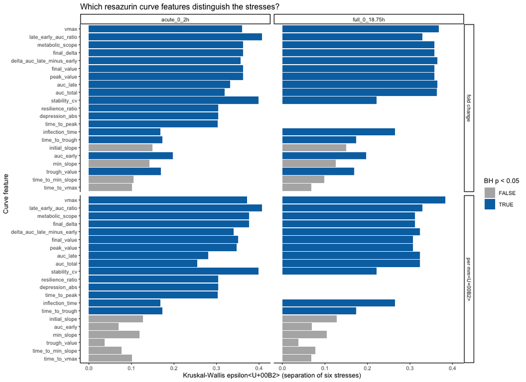

```r
p_screen <- feature_stress_screen %>%
  mutate(value_metric = recode(value_metric,
           fold_change = "fold change",
           metabolism_per_area_mm2_measurement = "per mm²")) %>%
  ggplot(aes(epsilon_sq, reorder(feature, epsilon_sq), fill = kw_p_bh < 0.05)) +
  geom_col() +
  facet_grid(value_metric ~ window) +
  scale_fill_manual(values = c("FALSE" = "grey70", "TRUE" = "#0072B2"),
                    name = "BH p < 0.05") +
  labs(x = "Kruskal-Wallis epsilon² (separation of six stresses)",
       y = "Curve feature",
       title = "Which resazurin curve features distinguish the stresses?") +
  theme_classic(base_size = 10)
p_screen
```

```r
ggsave(file.path(fig_dir, "feature_stress_screen.png"), p_screen,
       width = 11, height = 8)
```

# 7 Each Stress on Its Own

## 7.1 Stress feature profiles

Median of each feature per stress, z-scored across stresses, for the leading window × metric. Each column is one stress’s metabolic signature.

```r
best_ctx <- feature_stress_screen %>%
  group_by(window, value_metric) %>%
  summarise(mean_top5 = mean(sort(epsilon_sq, decreasing = TRUE)[1:5]),
            .groups = "drop") %>%
  slice_max(mean_top5, n = 1)
best_window <- best_ctx$window
best_metric <- best_ctx$value_metric
cat("Leading context: window =", best_window, "| metric =", best_metric, "\n")
```

```
Leading context: window = acute_0_2h | metric = metabolism_per_area_mm2_measurement
```

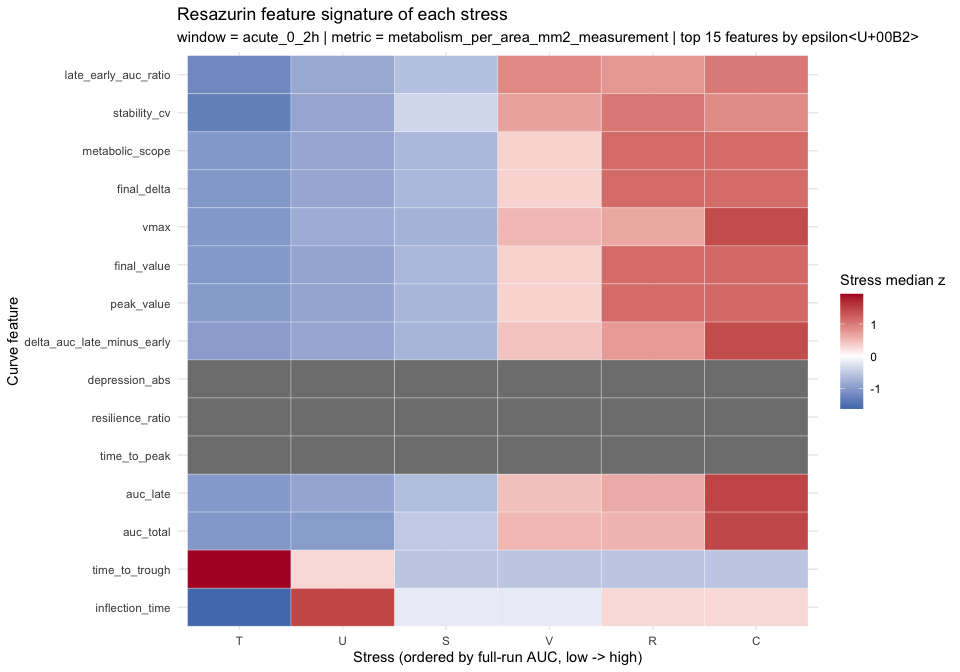

```r
stress_feature_profile <- feature_long %>%
  group_by(window, value_metric, feature, treatment_group) %>%
  summarise(median = median(value), mean = mean(value), .groups = "drop")
write_csv(stress_feature_profile, file.path(out_dir, "stress_feature_profile.csv"))

profile_features <- feature_stress_screen %>%
  filter(window == best_window, value_metric == best_metric) %>%
  slice_max(epsilon_sq, n = 15, with_ties = FALSE) %>%
  pull(feature)

severity_order <- stress_feature_profile %>%
  filter(window == "full_0_18.75h", value_metric == "fold_change",
         feature == "auc_total") %>%
  arrange(median) %>% pull(treatment_group)

p_prof <- stress_feature_profile %>%
  filter(window == best_window, value_metric == best_metric,
         feature %in% profile_features) %>%
  group_by(feature) %>%
  mutate(z = as.numeric(scale(median))) %>%
  ungroup() %>%
  mutate(treatment_group = factor(toupper(treatment_group),
                                  levels = toupper(severity_order)),
         feature = factor(feature, levels = rev(profile_features))) %>%
  ggplot(aes(treatment_group, feature, fill = z)) +
  geom_tile(color = "white") +
  scale_fill_gradient2(low = "#2166AC", mid = "white", high = "#B2182B",
                       name = "Stress median z") +
  labs(x = "Stress (ordered by full-run AUC, low -> high)", y = "Curve feature",
       title = "Resazurin feature signature of each stress",
       subtitle = sprintf("window = %s | metric = %s | top 15 features by epsilon²",
                          best_window, best_metric)) +
  theme_minimal(base_size = 11)
p_prof
```

```r
ggsave(file.path(fig_dir, "stress_signature_heatmap.png"), p_prof,
       width = 10, height = 7)
```

## 7.2 What sets each stress apart (one-vs-rest)

For each stress separately, Cliff’s delta of every feature in that stress vs the other five pooled (positive = higher in this stress), with Wilcoxon p BH-adjusted within stress.

```r
stress_signature <- feature_long %>%
  group_by(window, value_metric, feature) %>%
  group_modify(function(df, key) {
    map_dfr(stress_levels, function(g) {
      x <- df$value[df$treatment_group == g]
      y <- df$value[df$treatment_group != g]
      tibble(stress = g,
             median_stress = median(x), median_rest = median(y),
             cliffs_delta = cliffs_delta(x, y),
             wilcox_p = suppressWarnings(wilcox.test(x, y)$p.value))
    })
  }) %>%
  ungroup() %>%
  group_by(stress) %>%
  mutate(wilcox_p_bh = p.adjust(wilcox_p, "BH")) %>%
  ungroup()

write_csv(stress_signature, file.path(out_dir, "stress_signature_one_vs_rest.csv"))

top_by_stress <- stress_signature %>%
  group_by(stress) %>%
  slice_max(abs(cliffs_delta), n = 3, with_ties = FALSE) %>%
  ungroup()

knitr::kable(
  top_by_stress %>%
    transmute(stress = toupper(stress), window, value_metric, feature,
              median_stress = signif(median_stress, 3),
              median_rest = signif(median_rest, 3),
              cliffs_delta = round(cliffs_delta, 2),
              wilcox_p_bh = signif(wilcox_p_bh, 2)),
  caption = "Three most distinctive features of each stress (vs the other five)"
)
```

| stress | window | value_metric | feature | median_stress | median_rest | cliffs_delta | wilcox_p_bh |
| --- | --- | --- | --- | --- | --- | --- | --- |
| C | full_0_18.75h | fold_change | final_delta | 25.8000 | 9.4800 | 0.49 | 0.0980 |
| C | full_0_18.75h | fold_change | final_value | 26.8000 | 10.5000 | 0.49 | 0.0980 |
| C | full_0_18.75h | fold_change | metabolic_scope | 25.8000 | 9.4800 | 0.49 | 0.0980 |
| R | acute_0_2h | fold_change | stability_cv | 0.7070 | 0.4490 | 0.56 | 0.0450 |
| R | acute_0_2h | metabolism_per_area_mm2_measurement | stability_cv | 0.7070 | 0.4490 | 0.56 | 0.0450 |
| R | acute_0_2h | metabolism_per_area_mm2_measurement | final_value | 0.0514 | 0.0202 | 0.54 | 0.0450 |
| S | acute_0_2h | fold_change | late_early_auc_ratio | 2.3700 | 3.7200 | -0.30 | 0.6400 |
| S | acute_0_2h | metabolism_per_area_mm2_measurement | late_early_auc_ratio | 2.3700 | 3.7200 | -0.30 | 0.6400 |
| S | acute_0_2h | fold_change | stability_cv | 0.2950 | 0.5860 | -0.30 | 0.6400 |
| T | full_0_18.75h | fold_change | auc_late | 21.1000 | 180.0000 | -0.60 | 0.0046 |
| T | full_0_18.75h | fold_change | delta_auc_late_minus_early | 20.4000 | 179.0000 | -0.60 | 0.0046 |
| T | full_0_18.75h | fold_change | auc_total | 21.9000 | 181.0000 | -0.60 | 0.0046 |
| U | acute_0_2h | metabolism_per_area_mm2_measurement | peak_value | 0.0121 | 0.0332 | -0.47 | 0.0760 |
| U | acute_0_2h | metabolism_per_area_mm2_measurement | final_value | 0.0121 | 0.0332 | -0.47 | 0.0760 |
| U | acute_0_2h | fold_change | stability_cv | 0.1550 | 0.5860 | -0.46 | 0.0760 |
| V | acute_0_2h | fold_change | late_early_auc_ratio | 4.0700 | 2.7900 | 0.46 | 0.2700 |
| V | acute_0_2h | metabolism_per_area_mm2_measurement | late_early_auc_ratio | 4.0700 | 2.7900 | 0.46 | 0.2700 |
| V | acute_0_2h | fold_change | vmax | 3.1400 | 1.7700 | 0.39 | 0.2700 |

Three most distinctive features of each stress (vs the other five)

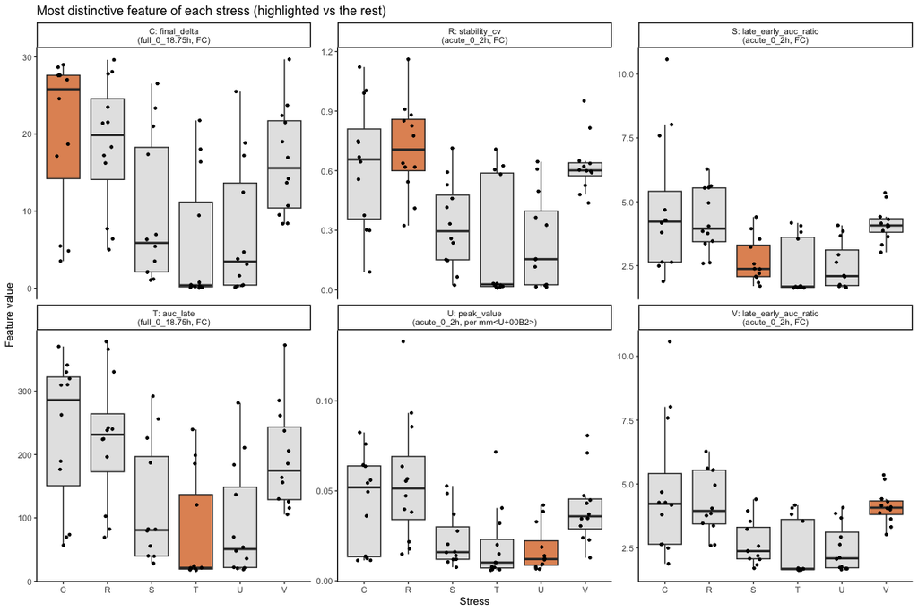

```r
top1 <- top_by_stress %>% group_by(stress) %>% slice_head(n = 1) %>% ungroup()

p_top1 <- top1 %>%
  select(stress, window, value_metric, feature) %>%
  left_join(feature_long, by = c("window", "value_metric", "feature"),
            relationship = "many-to-many") %>%
  mutate(panel = sprintf("%s: %s\n(%s, %s)", toupper(stress), feature, window,
                         ifelse(value_metric == "fold_change", "FC", "per mm²")),
         highlight = treatment_group == stress,
         treatment_group = factor(toupper(treatment_group), levels = toupper(stress_levels))) %>%
  ggplot(aes(treatment_group, value, fill = highlight)) +
  geom_boxplot(outlier.shape = NA, alpha = 0.7) +
  geom_jitter(width = 0.15, size = 0.9) +
  facet_wrap(~ panel, scales = "free_y") +
  scale_fill_manual(values = c("FALSE" = "grey85", "TRUE" = "#D55E00"), guide = "none") +
  labs(x = "Stress", y = "Feature value",
       title = "Most distinctive feature of each stress (highlighted vs the rest)") +
  theme_classic(base_size = 10)
p_top1
```

```r
ggsave(file.path(fig_dir, "most_distinctive_feature_per_stress.png"), p_top1,
       width = 12, height = 8)
```

# 8 Cross-validated Prediction (leave-one-oyster-out)

A screen over ~80 features × contexts overfits easily. As in 04, the honest test is out-of-sample: **leave one oyster out**, select the top-*k* features by ε² *using only the remaining 71 oysters*, fit a linear discriminant analysis (LDA) on the z-scored features, and predict the held-out oyster’s stress. Chance accuracy with six balanced classes is 1/6 ≈ 0.17.

```r
loo_lda <- function(wide, k) {
  # wide: trace_id, treatment_group, feature columns
  feats_all <- setdiff(names(wide), c("trace_id", "treatment_group"))
  y <- factor(wide$treatment_group, levels = stress_levels)
  preds <- character(nrow(wide))
  for (i in seq_len(nrow(wide))) {
    train <- wide[-i, ]
    # feature selection inside the fold (no leakage)
    eps <- map_dbl(feats_all, function(f) {
      v <- train[[f]]
      if (sd(v) == 0) return(-Inf)
      unname(kruskal.test(v ~ factor(train$treatment_group))$statistic)
    })
    feats <- feats_all[order(eps, decreasing = TRUE)][seq_len(k)]
    mu <- map_dbl(feats, ~ mean(train[[.x]]))
    sdv <- map_dbl(feats, ~ sd(train[[.x]]))
    xtr <- scale(as.matrix(train[, feats]), center = mu, scale = sdv)
    xte <- scale(as.matrix(wide[i, feats]), center = mu, scale = sdv)
    fit <- tryCatch(MASS::lda(xtr, grouping = y[-i], tol = 1e-8),
                    error = function(e) NULL)
    preds[i] <- if (is.null(fit)) NA_character_ else
      as.character(predict(fit, xte)$class)
  }
  tibble(trace_id = wide$trace_id, observed = as.character(y), predicted = preds)
}
```

```r
set.seed(20260921)
ks <- c(1, 2, 3, 5, 8)

contexts <- distinct(feature_long, window, value_metric)

loo_results <- contexts %>%
  pmap_dfr(function(window, value_metric) {
    wide <- feature_long %>%
      filter(window == !!window, value_metric == !!value_metric) %>%
      select(trace_id, treatment_group, feature, value) %>%
      pivot_wider(names_from = feature, values_from = value) %>%
      drop_na()
    map_dfr(ks, function(k) {
      loo_lda(wide, k) %>% mutate(window = window, value_metric = value_metric, k = k)
    })
  })

loo_cv_performance <- loo_results %>%
  group_by(window, value_metric, k) %>%
  summarise(n = n(),
            accuracy = mean(predicted == observed, na.rm = TRUE),
            .groups = "drop") %>%
  mutate(chance = 1 / length(stress_levels),
         # one-sided binomial test vs chance
         binom_p = map2_dbl(round(accuracy * n), n,
                            ~ binom.test(.x, .y, p = 1 / length(stress_levels),
                                         alternative = "greater")$p.value)) %>%
  arrange(desc(accuracy))

write_csv(loo_cv_performance, file.path(out_dir, "loo_cv_performance.csv"))

knitr::kable(
  loo_cv_performance %>%
    mutate(accuracy = round(accuracy, 3), binom_p = signif(binom_p, 3)),
  caption = "Leave-one-oyster-out LDA: accuracy of predicting stress from curve features"
)
```

| window | value_metric | k | n | accuracy | chance | binom_p |
| --- | --- | --- | --- | --- | --- | --- |
| acute_0_2h | fold_change | 8 | 72 | 0.403 | 0.1666667 | 1.70e-06 |
| acute_0_2h | fold_change | 5 | 72 | 0.333 | 0.1666667 | 4.23e-04 |
| acute_0_2h | metabolism_per_area_mm2_measurement | 5 | 72 | 0.333 | 0.1666667 | 4.23e-04 |
| acute_0_2h | metabolism_per_area_mm2_measurement | 8 | 72 | 0.333 | 0.1666667 | 4.23e-04 |
| acute_0_2h | fold_change | 2 | 72 | 0.222 | 0.1666667 | 1.35e-01 |
| acute_0_2h | metabolism_per_area_mm2_measurement | 2 | 72 | 0.222 | 0.1666667 | 1.35e-01 |
| full_0_18.75h | fold_change | 5 | 72 | 0.222 | 0.1666667 | 1.35e-01 |
| full_0_18.75h | fold_change | 8 | 72 | 0.222 | 0.1666667 | 1.35e-01 |
| acute_0_2h | metabolism_per_area_mm2_measurement | 3 | 72 | 0.194 | 0.1666667 | 3.08e-01 |
| full_0_18.75h | metabolism_per_area_mm2_measurement | 8 | 72 | 0.167 | 0.1666667 | 5.49e-01 |
| acute_0_2h | fold_change | 3 | 72 | 0.139 | 0.1666667 | 7.81e-01 |
| full_0_18.75h | fold_change | 2 | 72 | 0.111 | 0.1666667 | 9.29e-01 |
| full_0_18.75h | fold_change | 1 | 72 | 0.083 | 0.1666667 | 9.87e-01 |
| full_0_18.75h | fold_change | 3 | 72 | 0.083 | 0.1666667 | 9.87e-01 |
| full_0_18.75h | metabolism_per_area_mm2_measurement | 3 | 72 | 0.069 | 0.1666667 | 9.96e-01 |
| full_0_18.75h | metabolism_per_area_mm2_measurement | 5 | 72 | 0.069 | 0.1666667 | 9.96e-01 |
| full_0_18.75h | metabolism_per_area_mm2_measurement | 2 | 72 | 0.042 | 0.1666667 | 1.00e+00 |
| acute_0_2h | fold_change | 1 | 72 | 0.028 | 0.1666667 | 1.00e+00 |
| acute_0_2h | metabolism_per_area_mm2_measurement | 1 | 72 | 0.028 | 0.1666667 | 1.00e+00 |
| full_0_18.75h | metabolism_per_area_mm2_measurement | 1 | 72 | 0.000 | 0.1666667 | 1.00e+00 |

Leave-one-oyster-out LDA: accuracy of predicting stress from curve features

## 8.1 Best model: confusion matrix

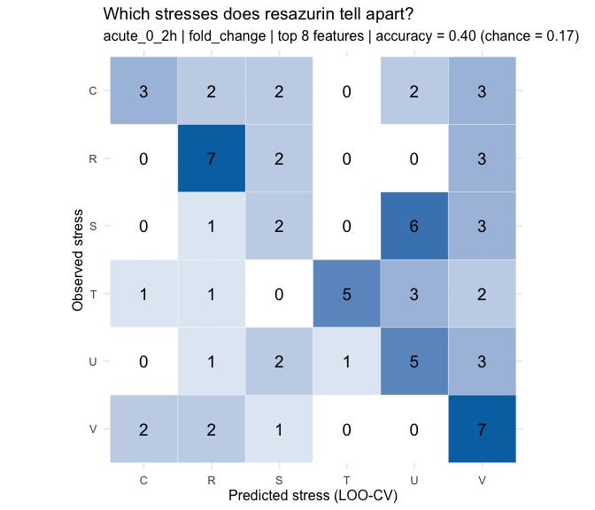

```r
best_model <- loo_cv_performance %>% slice_max(accuracy, n = 1, with_ties = FALSE)

loo_cv_predictions <- loo_results %>%
  semi_join(best_model, by = c("window", "value_metric", "k"))
write_csv(loo_cv_predictions, file.path(out_dir, "loo_cv_predictions.csv"))

conf <- loo_cv_predictions %>%
  count(observed, predicted) %>%
  complete(observed = stress_levels, predicted = stress_levels, fill = list(n = 0)) %>%
  mutate(across(c(observed, predicted), ~ factor(toupper(.x), levels = toupper(stress_levels))))

p_conf <- ggplot(conf, aes(predicted, fct_rev(observed), fill = n)) +
  geom_tile(color = "white") +
  geom_text(aes(label = n), size = 5) +
  scale_fill_gradient(low = "white", high = "#0072B2", guide = "none") +
  coord_equal() +
  labs(x = "Predicted stress (LOO-CV)", y = "Observed stress",
       title = "Which stresses does resazurin tell apart?",
       subtitle = sprintf("%s | %s | top %d features | accuracy = %.2f (chance = %.2f)",
                          best_model$window, best_model$value_metric, best_model$k,
                          best_model$accuracy, best_model$chance)) +
  theme_minimal(base_size = 12)
p_conf
```

```r
ggsave(file.path(fig_dir, "loo_cv_confusion_matrix.png"), p_conf,
       width = 7, height = 6)

per_stress_acc <- loo_cv_predictions %>%
  group_by(stress = observed) %>%
  summarise(n = n(), recall = mean(predicted == observed), .groups = "drop")
knitr::kable(per_stress_acc %>% mutate(stress = toupper(stress), recall = round(recall, 2)),
             caption = "Per-stress LOO-CV recall (best model)")
```

| stress | n | recall |
| --- | --- | --- |
| C | 12 | 0.25 |
| R | 12 | 0.58 |
| S | 12 | 0.17 |
| T | 12 | 0.42 |
| U | 12 | 0.42 |
| V | 12 | 0.58 |

Per-stress LOO-CV recall (best model)

# 9 Composite Stress Index

As in 04’s resazurin index, the leading features are combined into one axis. Two complementary summaries:

1. **PCA** of the top features (z-scored). Shows whether the stresses fall along one gradient or several.
2. **Suppression index**: the mean of the z-scored top features, with each feature’s sign aligned to full-run fold-change AUC. Higher = more metabolic activity. Stresses are ranked on it, and its stability is checked by leave-one-oyster-out (the index weights are recomputed without each oyster).

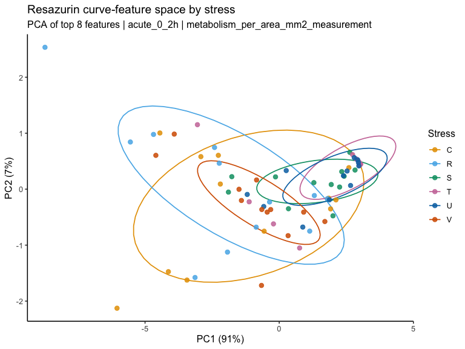

```r
idx_features <- feature_stress_screen %>%
  filter(window == best_window, value_metric == best_metric) %>%
  slice_max(epsilon_sq, n = 8, with_ties = FALSE) %>%
  pull(feature)

idx_wide <- feature_long %>%
  filter(window == best_window, value_metric == best_metric,
         feature %in% idx_features) %>%
  select(trace_id, treatment_group, feature, value) %>%
  pivot_wider(names_from = feature, values_from = value) %>%
  drop_na()

pca <- prcomp(idx_wide[, idx_features], center = TRUE, scale. = TRUE)
var_expl <- summary(pca)$importance[2, 1:2]

pca_df <- bind_cols(idx_wide %>% select(trace_id, treatment_group),
                    as_tibble(pca$x[, 1:2]))

p_pca <- ggplot(pca_df, aes(PC1, PC2, color = treatment_group)) +
  stat_ellipse(level = 0.68, linewidth = 0.6) +
  geom_point(size = 2.3, alpha = 0.85) +
  scale_color_manual(values = stress_pal, labels = toupper, name = "Stress") +
  labs(x = sprintf("PC1 (%.0f%%)", 100 * var_expl[1]),
       y = sprintf("PC2 (%.0f%%)", 100 * var_expl[2]),
       title = "Resazurin curve-feature space by stress",
       subtitle = sprintf("PCA of top %d features | %s | %s",
                          length(idx_features), best_window, best_metric)) +
  theme_classic(base_size = 12)
p_pca
```

```r
ggsave(file.path(fig_dir, "feature_pca_by_stress.png"), p_pca, width = 8, height = 6)

knitr::kable(round(pca$rotation[, 1:2], 2), caption = "PCA loadings")
```

|  | PC1 | PC2 |
| --- | --- | --- |
| late_early_auc_ratio | -0.32 | -0.63 |
| stability_cv | -0.32 | -0.60 |
| metabolic_scope | -0.37 | 0.18 |
| final_delta | -0.37 | 0.18 |
| vmax | -0.36 | -0.01 |
| final_value | -0.36 | 0.23 |
| peak_value | -0.36 | 0.24 |
| delta_auc_late_minus_early | -0.36 | 0.26 |

PCA loadings

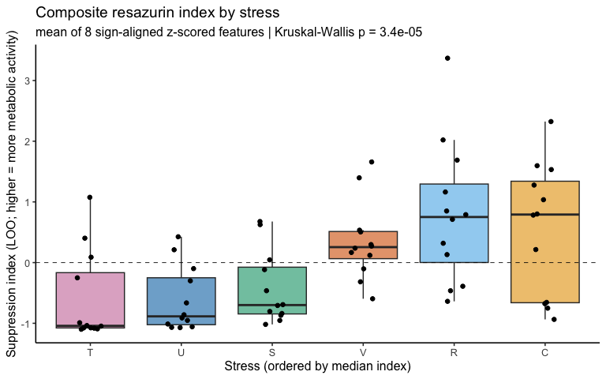

```r
anchor <- curve_features %>%
  filter(window == "full_0_18.75h", value_metric == "fold_change") %>%
  select(trace_id, anchor_auc = auc_total)

idx_df <- idx_wide %>% left_join(anchor, by = "trace_id")

compute_index <- function(train, test) {
  signs <- map_dbl(idx_features, ~ sign(cor(train[[.x]], train$anchor_auc,
                                            method = "spearman")))
  z <- map2(idx_features, signs, function(f, s) {
    s * (test[[f]] - mean(train[[f]])) / sd(train[[f]])
  })
  rowMeans(do.call(cbind, z))
}

idx_df$suppression_index <- compute_index(idx_df, idx_df)
idx_df$suppression_index_loo <- map_dbl(seq_len(nrow(idx_df)),
  ~ compute_index(idx_df[-.x, ], idx_df[.x, ]))

stress_index <- idx_df %>%
  select(trace_id, treatment_group, suppression_index, suppression_index_loo) %>%
  left_join(pca_df %>% select(trace_id, PC1, PC2), by = "trace_id")
write_csv(stress_index, file.path(out_dir, "stress_index.csv"))

idx_kw <- kruskal.test(suppression_index_loo ~ factor(treatment_group), data = stress_index)

idx_order <- stress_index %>%
  group_by(treatment_group) %>%
  summarise(median_idx = median(suppression_index_loo), .groups = "drop") %>%
  arrange(median_idx)

p_idx <- stress_index %>%
  mutate(treatment_group = factor(treatment_group, levels = idx_order$treatment_group)) %>%
  ggplot(aes(treatment_group, suppression_index_loo, fill = treatment_group)) +
  geom_boxplot(outlier.shape = NA, alpha = 0.6) +
  geom_jitter(width = 0.15, size = 1.6) +
  geom_hline(yintercept = 0, linetype = 2, linewidth = 0.3) +
  scale_fill_manual(values = stress_pal, guide = "none") +
  scale_x_discrete(labels = toupper) +
  labs(x = "Stress (ordered by median index)",
       y = "Suppression index (LOO; higher = more metabolic activity)",
       title = "Composite resazurin index by stress",
       subtitle = sprintf("mean of %d sign-aligned z-scored features | Kruskal-Wallis p = %.2g",
                          length(idx_features), idx_kw$p.value)) +
  theme_classic(base_size = 12)
p_idx
```

```r
ggsave(file.path(fig_dir, "suppression_index_by_stress.png"), p_idx,
       width = 8, height = 5)

knitr::kable(idx_order %>% mutate(treatment_group = toupper(treatment_group),
                                  median_idx = round(median_idx, 2)),
             caption = "Stresses ranked by composite suppression index (low = most suppressed)")
```

| treatment_group | median_idx |
| --- | --- |
| T | -1.04 |
| U | -0.89 |
| S | -0.70 |
| V | 0.25 |
| R | 0.75 |
| C | 0.79 |

Stresses ranked by composite suppression index (low = most suppressed)

# 10 Synthesis

```r
top3 <- feature_stress_screen %>% slice_head(n = 3)

cat("## Screening result\n\n")
```

## 10.1 Screening result

```r
cat("Features that best separate the six stresses:\n\n")
```

Features that best separate the six stresses:

```r
for (i in seq_len(nrow(top3))) {
  cat(sprintf("- **%s** (%s / %s): epsilon² = %.2f (BH p = %.2g)\n",
              top3$feature[i], top3$value_metric[i], top3$window[i],
              top3$epsilon_sq[i], top3$kw_p_bh[i]))
}
```

- **late_early_auc_ratio** (fold_change / acute_0_2h): epsilon² = 0.41 (BH p = 0.00043)
- **late_early_auc_ratio** (metabolism_per_area_mm2_measurement / acute_0_2h): epsilon² = 0.41 (BH p = 0.00043)
- **stability_cv** (fold_change / acute_0_2h): epsilon² = 0.40 (BH p = 0.00043)

```r
cat("\n## Cross-validated result\n\n")
```

## 10.2 Cross-validated result

```r
cat(sprintf(
  "Best leave-one-oyster-out model: %s / %s with top %d features, accuracy = %.2f vs chance %.2f (binomial p = %.2g).\n\n",
  best_model$window, best_model$value_metric, best_model$k,
  best_model$accuracy, best_model$chance, best_model$binom_p))
```

Best leave-one-oyster-out model: acute_0_2h / fold_change with top 8 features, accuracy = 0.40 vs chance 0.17 (binomial p = 1.7e-06).

```r
cat("Per-stress recall: ",
    paste(sprintf("%s = %.2f", toupper(per_stress_acc$stress), per_stress_acc$recall),
          collapse = ", "), "\n\n")
```

Per-stress recall: C = 0.25, R = 0.58, S = 0.17, T = 0.42, U = 0.42, V = 0.58

```r
cat("## Each stress\n\n")
```

## 10.3 Each stress

```r
for (g in stress_levels) {
  tb <- top_by_stress %>% filter(stress == g) %>% slice_head(n = 1)
  cat(sprintf("- **Stress %s**: most distinctive feature `%s` (%s, %s), median %.3g vs %.3g in the other stresses (Cliff's d = %.2f).\n",
              toupper(g), tb$feature, tb$window,
              ifelse(tb$value_metric == "fold_change", "fold change", "per mm²"),
              tb$median_stress, tb$median_rest, tb$cliffs_delta))
}
```

- **Stress C**: most distinctive feature `final_delta` (full_0_18.75h, fold change), median 25.8 vs 9.48 in the other stresses (Cliff’s d = 0.49).
- **Stress R**: most distinctive feature `stability_cv` (acute_0_2h, fold change), median 0.707 vs 0.449 in the other stresses (Cliff’s d = 0.56).
- **Stress S**: most distinctive feature `late_early_auc_ratio` (acute_0_2h, fold change), median 2.37 vs 3.72 in the other stresses (Cliff’s d = -0.30).
- **Stress T**: most distinctive feature `auc_late` (full_0_18.75h, fold change), median 21.1 vs 180 in the other stresses (Cliff’s d = -0.60).
- **Stress U**: most distinctive feature `peak_value` (acute_0_2h, per mm²), median 0.0121 vs 0.0332 in the other stresses (Cliff’s d = -0.47).
- **Stress V**: most distinctive feature `late_early_auc_ratio` (acute_0_2h, fold change), median 4.07 vs 2.79 in the other stresses (Cliff’s d = 0.46).

```r
cat(sprintf("\nComposite index order (most → least suppressed): %s.\n",
            paste(toupper(idx_order$treatment_group), collapse = " < ")))
```

Composite index order (most → least suppressed): T < U < S < V < R < C.

## 10.4 Interpretation

The tables above are regenerated on every render. Read them with these points in mind:

- **Magnitude vs shape.** If the leading features are capacity traits (AUC, vmax, final value), the stresses differ mainly in *how much* metabolism they allow. If timing and ratio features (time to vmax, late/early ratio, resilience ratio) also rank highly, the stresses differ in *how* the response unfolds. That is the stronger basis for fingerprinting stresses from resazurin alone.
- **Confusion structure.** Stresses that are confused with one another in the LOO-CV matrix produce indistinguishable resazurin phenotypes at this sampling density, even if their mean AUCs differ.
- **Plate confound.** With one plate per stress, a replicated design (≥ 2 plates per stress, positions randomised) is needed before a stress signature can be separated from a plate effect.

## 10.5 Recommended next steps

1. Add stress names to `layout.csv` (`treatment.group`) and re-render 05.00 → 05.1.
2. Replicate plates within each stress to break the plate × stress confound.
3. Add reads between 2 h and 18.75 h: the overnight gap leaves most shape features unresolved.
4. If these animals are followed for survival, join per-individual survival to `stress_index.csv` and test whether the index predicts outcome within each stress (the individual-level version of notebook 04).